# lab3_assembly_annotation2.0

2025-09-25

#SETUP

```bash
docker pull quay.io/biocontainers/quast:5.3.0--py313pl5321h5ca1c30_2
```

### Load the packages

```r
library("IRanges")
library("GenomicRanges")
library("Rsamtools")
library("GenomicAlignments")
```

```r
library("Gviz")
```

### Download the reference genome (Recall: fna = reference)

```bash
curl -O https://ftp.ncbi.nlm.nih.gov/genomes/refseq/fungi/Saccharomyces_cerevisiae/latest_assembly_versions/GCF_000146045.2_R64/GCF_000146045.2_R64_genomic.fna.gz

gunzip GCF_000146045.2_R64_genomic.fna.gz
```

### Download the genome annotations (Recall: gff = annotations)

```bash
curl -O https://ftp.ncbi.nlm.nih.gov/genomes/refseq/fungi/Saccharomyces_cerevisiae/latest_assembly_versions/GCF_000146045.2_R64/GCF_000146045.2_R64_genomic.gff.gz

gunzip GCF_000146045.2_R64_genomic.gff.gz
```

# 4 - ASSEMBLE GENOME (NOTICE MISTAKE IN .fastq file -> changed to end in 001)

(takes a while)

```bash
flye --nano-raw ERR1539001.fastq --out-dir flye_output --threads 8 --genome-size 12m
```

# QUESTION 1

**JUST MANUALLY GO TO END Assembly statistics:

```
Total length:   12706271
Fragments:  354
Fragments N50:  52932
Largest frg:    302366
Scaffolds:  0
Mean coverage:  8
```

Based on the summary alignment statistics (found at the end of the flye_output/flye.log), we must look at a few things to consider if the coverage of the assembly is adequate. Given the total fragments is 354 and the N50 (when thinking of it as the mean/median of fragment lengths) is not even half the total length of the genome, this indicates low contiguous assemblies. Additionally, the mean coverage is only 8 (ie each base on average is seen in 8 reads), further supporting that coverage is not adequate and rather low

# 5 - EVALUATE ASSEMBLY

### 5.1 USING BUSCO (takes a while)

```bash
docker run --rm \
  -v "$PWD":/data \
  -w /data \
  ezlabgva/busco:v6.0.0_cv1 \
  busco -i assembly.fasta -o busco_output -l saccharomycetaceae_odb12 -m genome -c 8
```

# QUESTION 2

**FROM TXT FILE** *** Results: *****

```
C:33.7%[S:33.6%,D:0.1%],F:0.4%,M:65.9%,n:3282,E:5.2%
1107    Complete BUSCOs (C) (of which 58 contain internal stop codons)
1104    Complete and single-copy BUSCOs (S)
3   Complete and duplicated BUSCOs (D)
13  Fragmented BUSCOs (F)
2162    Missing BUSCOs (M)
3282    Total BUSCO groups searched
```

Assembly Statistics: 354 Number of scaffolds 354 Number of contigs 12706271 Total length 0.000% Percent gaps 52 kbp Scaffold N50 52 kbp Contigs N50

1. BUSCO SCORES C:33.7%[S:33.6%,D:0.1%],F:0.4%,M:65.9%,n:3282,E:5.2% C - lvl of completeness (S = unique, D = duplicated) The gene is uniquely found within 33.6% of the comparison of assemblies and has minimal duplication F - the lvl of fragmentation = 0.4% -> limited fragmentation means more complete assemblies M - lvl of how much the assembly is missing = 65.9% -> huge proportion of gene is unknown Given the coverage, although the assembly of the gene that is known is unique for the most part, a large portion of the assembly is unknown indicating coverage is limited and is not the best

ii/iii) ASSEMBLY STATISTICS N50 is 52kbp (scaffolds and contigs). Compared to flye results, it is about the same which again indicates low contiguity and therefore, low coverage. Total assembly length is 12706271

### 5.2 USING QUAST (fast)

```bash
docker run --rm -v "$(pwd)":/data -w /data quay.io/biocontainers/quast:5.3.0--py313pl5321h5ca1c30_2 \
  quast.py assembly.fasta \
  -r GCF_000146045.2_R64_genomic.fna \
  -g GCF_000146045.2_R64_genomic.gff \
  -o quast_output
```

# QUESTION 3

Alignment-based statistics assembly Genome fraction (%) 0.529 Duplication ratio 1.157 # genomic features 160 + 46 part Largest alignment 34624 Total aligned length 74454 NGA50 - LGA50 - Misassemblies  
# misassemblies 0 Misassembled contigs length 0 Per base quality  
# mismatches per 100 kbp 1177.91 # indels per 100 kbp 2815.16 # N’s per 100 kbp 0 Statistics without reference  
# contigs 354 Largest contig 302366 Total length 12706271 Total length (>= 1000 bp) 12706271 Total length (>= 10000 bp) 12450048 Total length (>= 50000 bp) 6677515

# 6 - ANNOTATING

# QUESTION 4

```r
library(Biostrings)

#load the full genome FASTA
genome <- readDNAStringSet("/Users/aaronsantos/GCF_000146045.2_R64_genomic.fna")

#extract chrom
chr1 <- genome[grep("chromosome I", names(genome), ignore.case = TRUE)]

#save
writeXStringSet(chr1, "R64_chr1.fna")
```

### 6.3

```bash
minimap2 -t 8 -ax asm5 R64_chr1.fna ./flye_output/assembly.fasta > contig_vs_chr1.sam
```

### convert sam to bam

```bash
samtools view -bS contig_vs_chr1.sam > alignment.bam
```

### sort aligned contigs (ie bam file)

```bash
samtools sort alignment.bam -o alignment.sorted.bam
```

### index sorted bam file

```bash
samtools index alignment.sorted.bam
```

### visualize alignment w/GRanges

###import bam file + convert into GRanges obj

```r
bam_file <- "alignment.sorted.bam"

#open connection to BAM file
bam <- BamFile(bam_file)

#read all alignments (already restricted to chr1)
alns <- readGAlignments(bam)

#convert to GRanges object
gr_alns <- granges(alns)
```

###create tracks

```r
#disable uscs-file name syntax
options(ucscChromosomeNames=FALSE)

aln_track <- AnnotationTrack(gr_alns, name = "Contigs", genome = "sacCer3", chromosome = "NC_001133.9")

# Add genome axis for scale
axis_track <- GenomeAxisTrack()
```

###visualize alignment

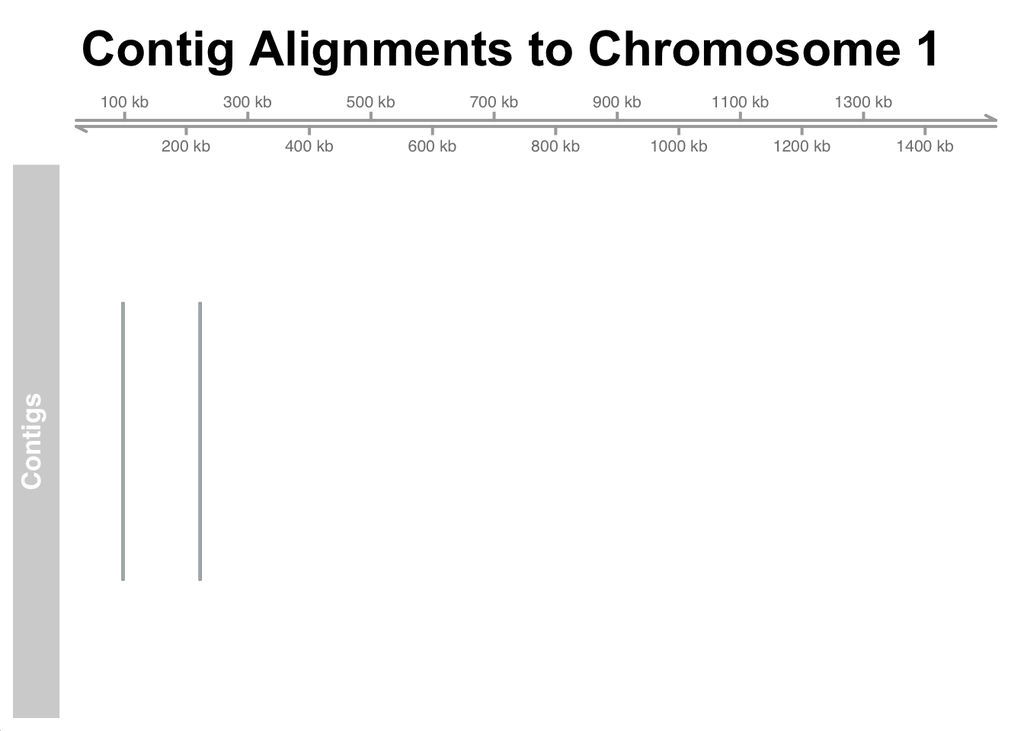

```r
plotTracks(list(axis_track, aln_track),
           from = min(start(gr_alns)),
           to = max(end(gr_alns)),
           main = "Contig Alignments to Chromosome 1")
```

# QUESTION 5

There were 2 contigs aligned to the chromosome

# QUESTION 6

```r
assembly <- readDNAStringSet("assembly.fasta")

#find the longest contig
lengths <- width(assembly)
longest_contig2.0 <- assembly[which.max(lengths)]

#save the longest contig
writeXStringSet(longest_contig2.0, "longest_contig.fasta")
```

```bash
minimap2 -ax splice -uf --secondary=no longest_contig.fasta GCF_000146045.2_R64_genomic.fna > cds_aln.sam
```

### QUESTION 7

```bash
#convert sam to bam file
samtools view -bS cds_aln.sam > cds_aln.bam

#sort aligned contigs
samtools sort cds_aln.bam -o cds_aln.sorted.bam

#index sorted bam -> creates .bai file
samtools index cds_aln.sorted.bam
```

### QUESTION 8

```r
#file path
bam_cds_file <- "cds_aln.sorted.bam"

#open cnnxn to BAM file
bam_cds <- BamFile(bam_cds_file)

#read all alignments
alns_cds <- readGAlignments(bam_cds)

#convert to GRanges object
gr_alns_cds <- granges(alns_cds)

options(ucscChromosomeNames = FALSE)

#checking name for chromosome parameter
unique(seqnames(gr_alns_cds))
```

```
## [1] contig_142
## Levels: contig_142
```

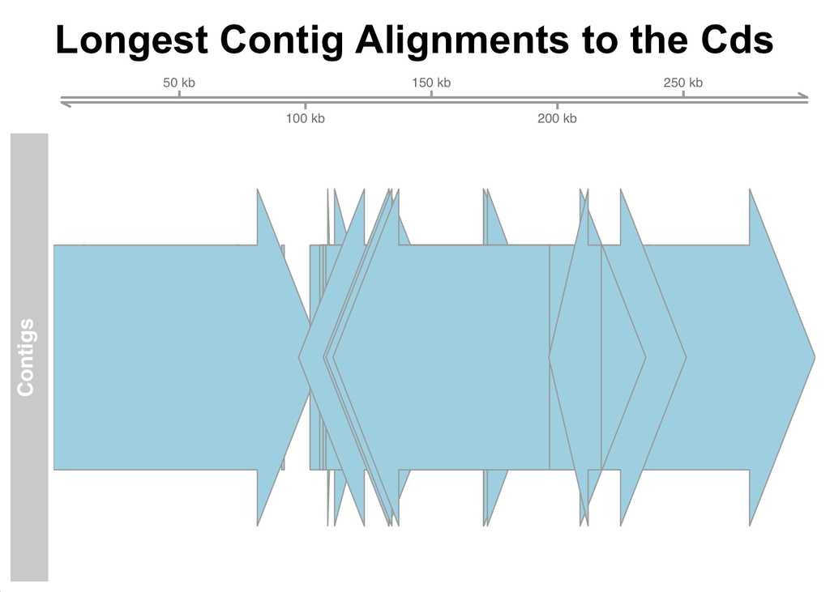

```r
#create tracks
aln_track_cds <- AnnotationTrack(gr_alns_cds, name = "Contigs", genome = "sacCer3", chromosome = "contig_142", stacking = "dense")

axis_track_cds <- GenomeAxisTrack()

#plot
plotTracks(list(axis_track_cds, aln_track_cds),
          from = min(start(gr_alns_cds)),
          to = max(end(gr_alns_cds)),
          main = "Longest Contig Alignments to the Cds")
```